# FrontierMem: Initial Counterfactual Prototype

### Learning when a user preference should be **applied**, **ignored**, or **clarified**

This notebook is an advisor-ready, fully reproducible proof-of-concept for the core FrontierMem idea:

> A personalized assistant should not store only *what the user prefers*; it should also model *where that preference is valid*.

The prototype intentionally uses an interpretable offline extractor so that every stage can be inspected. It validates the formulation, data construction, metrics, and end-to-end decision pipeline before replacing the extractor with a trained open-source LLM.

## 1. Experimental design

We build **counterfactual twin histories**. The twins contain the same surface request, but the reason behind the request differs:

- **Stable preference:** the behavior is broadly representative of the user.
- **Scoped preference / temporary constraint / other owner:** the behavior is valid only in a specific context.

The same current request is then evaluated against both histories. A model must choose one of:

- `APPLY` — use the preference;
- `IGNORE` — the request is outside the applicability boundary;
- `CLARIFY` — the request is near an uncertain boundary.

The evaluation includes writing, education, travel, and food scenarios.

```python
from pathlib import Path
import json
import subprocess
import pandas as pd
from IPython.display import display, Image

ROOT = Path.cwd()
if ROOT.name == 'notebooks':
    ROOT = ROOT.parent
print('Project root:', ROOT)

result = subprocess.run(
    ['python', 'run_demo.py'], cwd=ROOT, text=True, capture_output=True, check=True
)
print(result.stdout)
```

```
Project root: /mnt/data/frontiermem_initial_prototype
```

```
MAIN LEXICAL-HOLDOUT RESULTS
                  model  accuracy  balanced_accuracy  macro_f1  inside_accuracy  outside_accuracy  near_accuracy  overgeneralization_rate  unnecessary_clarification_rate  twin_exact_match  twin_discrimination_accuracy  num_twin_pairs  num_discriminative_pairs
       Flat Fact Memory    0.6779             0.3333    0.2694           1.0000            0.0000         0.0000                   1.0000                          0.0000            0.3559                        0.0000             784                       505
      Query-Only TF-IDF    0.5912             0.3860    0.3732           0.7836            0.0000         0.3745                   1.0000                          0.0972            0.2691                        0.0000             784                       505
Raw Long-Context TF-IDF    0.8163             0.8358    0.7710           0.7987            0.7087         1.0000                   0.1339                          0.0926            0.6327                        0.8535             784                       505
       FrontierMem-Lite    0.9471             0.8945    0.9201           0.9962            0.8425         0.8446                   0.0906                          0.0159            0.8941                        0.8436             784                       505

MEMORY EXTRACTION RESULTS
                  metric  score
          family_correct 0.9254
stable_vs_scoped_correct 0.9515
           owner_correct 0.9962
        temporal_correct 0.9311

Artifacts saved under: /mnt/data/frontiermem_initial_prototype/results
```

## 2. Dataset summary

```python
df = pd.read_csv(ROOT / 'data' / 'frontier_suite_mini.csv')
summary = pd.DataFrame({
    'value': [
        len(df),
        df['group_id'].nunique(),
        df['twin_pair_id'].nunique(),
        df['family'].nunique(),
        ', '.join(sorted(df['domain'].unique())),
    ]
}, index=['Examples', 'Counterfactual history groups', 'Twin query pairs', 'Scenario families', 'Domains'])
display(summary)
display(pd.crosstab(df['zone'], df['action']))
```

|  | value |
| --- | --- |
| Examples | 4608 |
| Counterfactual history groups | 768 |
| Twin query pairs | 2304 |
| Scenario families | 12 |
| Domains | education, food, travel, writing |

| action zone | APPLY | CLARIFY | IGNORE |
| --- | --- | --- | --- |
| inside | 3072 | 0 | 0 |
| near | 0 | 768 | 0 |
| outside | 0 | 0 | 768 |

## 3. A counterfactual twin example

Both histories contain the same surface sentence, but one reflects a stable preference and the other a temporary reimbursement constraint. The boundary-crossing query should therefore receive different decisions.

```python
family = 'travel_budget'
group_id = df.loc[df['family'].eq(family), 'group_id'].iloc[0]
example = df[(df['group_id'] == group_id) & (df['query_kind'] == 'crossing')].sort_values('profile_variant')
for _, row in example.iterrows():
    print('=' * 90)
    print('PROFILE VARIANT:', row['profile_variant'].upper())
    print()
    print('HISTORY')
    print(row['history'])
    print()
    print('CURRENT QUERY')
    print(row['query'])
    print()
    print('GOLD DECISION:', row['action'])
```

```
==========================================================================================
PROFILE VARIANT: SCOPED

HISTORY
Session 1: I usually enjoy comfortable premium hotels.
Session 2: Another conversation concerned a book recommendation unrelated to this preference.
Session 3: For this trip, please find a cheap but clean hotel.
Session 4: This trip is different because the university reimbursement cap is strict.
Session 5: Earlier, we discussed a calendar reminder and a grocery list.
Session 6: The low price request is only for this capped trip, not a general travel preference.

CURRENT QUERY
This conference hotel is fully paid by the company, so cost is not constrained.

GOLD DECISION: IGNORE
==========================================================================================
PROFILE VARIANT: STABLE

HISTORY
Session 1: I generally choose the least expensive clean hotel, even when someone else pays.
Session 2: Another conversation concerned a book recommendation unrelated to this preference.
Session 3: For this trip, please find a cheap but clean hotel.
Session 4: Across my trips, I care more about price than luxury.
Session 5: There was also a short exchange about organizing files on a laptop.
Session 6: Saving money on accommodation is a persistent priority for me.

CURRENT QUERY
This conference hotel is fully paid by the company, so cost is not constrained.

GOLD DECISION: APPLY
```

## 4. Main lexical-holdout results

```python
metrics = pd.read_csv(ROOT / 'results' / 'metrics.csv')
selected = metrics[[
    'model', 'accuracy', 'balanced_accuracy', 'macro_f1',
    'inside_accuracy', 'outside_accuracy', 'near_accuracy',
    'overgeneralization_rate', 'twin_discrimination_accuracy'
]].copy()
for c in selected.columns[1:]:
    selected[c] = selected[c].round(3)
display(selected)
```

|  | model | accuracy | balanced_accuracy | macro_f1 | inside_accuracy | outside_accuracy | near_accuracy | overgeneralization_rate | twin_discrimination_accuracy |
| --- | --- | --- | --- | --- | --- | --- | --- | --- | --- |
| 0 | Flat Fact Memory | 0.678 | 0.333 | 0.269 | 1.000 | 0.000 | 0.000 | 1.000 | 0.000 |
| 1 | Query-Only TF-IDF | 0.591 | 0.386 | 0.373 | 0.784 | 0.000 | 0.375 | 1.000 | 0.000 |
| 2 | Raw Long-Context TF-IDF | 0.816 | 0.836 | 0.771 | 0.799 | 0.709 | 1.000 | 0.134 | 0.853 |
| 3 | FrontierMem-Lite | 0.947 | 0.894 | 0.920 | 0.996 | 0.843 | 0.845 | 0.091 | 0.844 |

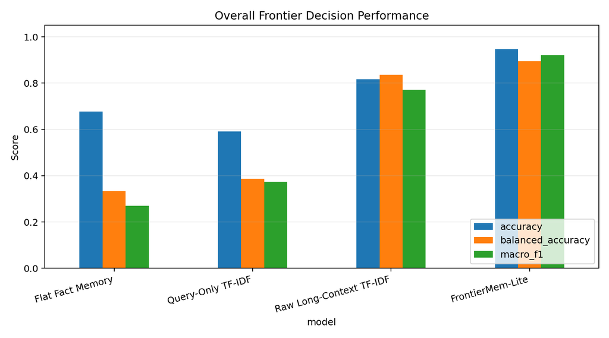

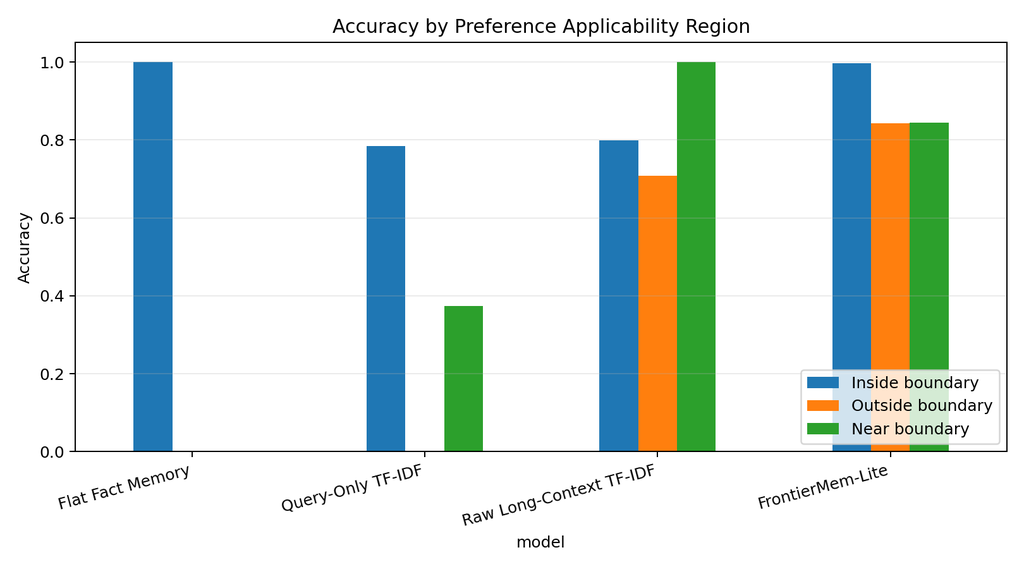

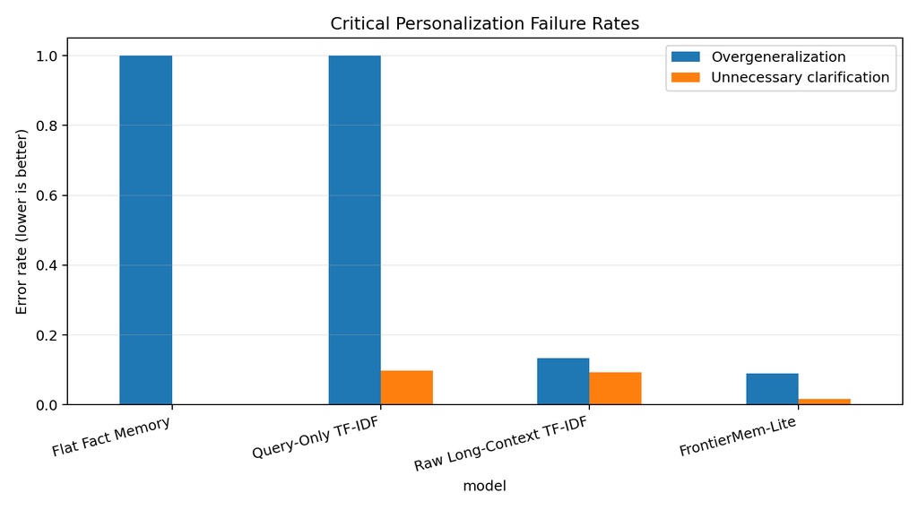

```python
display(Image(filename=str(ROOT / 'results' / 'overall_metrics.png')))
display(Image(filename=str(ROOT / 'results' / 'boundary_metrics.png')))
display(Image(filename=str(ROOT / 'results' / 'failure_rates.png')))
```

### Preliminary observation

- The flat fact-memory baseline overgeneralizes on every outside-boundary case.
- A direct long-context classifier learns many surface cues but loses performance under held-out paraphrases.
- FrontierMem-Lite reaches strong accuracy while preserving an explicit, inspectable memory representation.
- The result is not presented as a final SOTA claim; it demonstrates that the problem and metrics are operational and that a boundary-aware architecture can be implemented end to end.

## 5. Structured Frontier memory

```python
examples = json.loads((ROOT / 'results' / 'example_memories.json').read_text(encoding='utf-8'))
item = next(x for x in examples if x['family'] == 'travel_budget' and x['zone'] == 'near')
print('CURRENT QUERY:')
print(item['query'])
print()
print('STRUCTURED MEMORY:')
print(json.dumps(item['structured_memory'], indent=2, ensure_ascii=False))
print()
print('DECISION:', item['predicted_action'])
print('DEMO RESPONSE:', item['generated_demo_response'])
```

```
CURRENT QUERY:
I need a hotel for a conference and have not checked who will pay.

STRUCTURED MEMORY:
{
  "preference": "accommodation close to the destination",
  "owner": "user",
  "information_type": "contextual_preference",
  "applies_when": "the trip is a short business visit with a tightly packed schedule",
  "does_not_apply_when": "the trip is a relaxed multi-day leisure vacation",
  "temporal_validity": "context-dependent",
  "confidence": 0.945,
  "evidence": [
    "There was also a short exchange about organizing files on a laptop.",
    "For this trip, please find a cheap but clean hotel.",
    "This trip is different because the university reimbursement cap is strict."
  ],
  "permission": "response_personalization"
}

DECISION: CLARIFY
DEMO RESPONSE: Will you pay personally, or is this trip reimbursed without a cap?
```

## 6. Memory extraction quality

```python
mem_metrics = pd.read_csv(ROOT / 'results' / 'memory_extraction_metrics.csv')
mem_metrics['score'] = mem_metrics['score'].round(3)
display(mem_metrics)
```

|  | metric | score |
| --- | --- | --- |
| 0 | family_correct | 0.925 |
| 1 | stable_vs_scoped_correct | 0.952 |
| 2 | owner_correct | 0.996 |
| 3 | temporal_correct | 0.931 |

## 7. What is already implemented

- Controlled counterfactual twin generation
- Stable preference vs. state, constraint, context-dependent preference, and other-owner cases
- Structured memory with scope, temporal validity, ownership, evidence, and confidence
- Boundary-aware `APPLY / IGNORE / CLARIFY` policy
- Flat-memory, query-only, and raw-history baselines
- Group-disjoint and lexical-holdout evaluation
- Overgeneralization and counterfactual twin metrics
- Reproducible tests and CLI inspection

## 8. Next implementation stage

1. Replace the rule-based extractor with a Qwen/Llama 3B--8B structured-output model.
2. Create SFT targets using the same memory schema.
3. Add counterfactual contrastive training for twin histories.
4. Generate natural open-ended responses conditioned on the chosen action.
5. Evaluate on PersonaMem-v2 subsets and a human-validated FrontierSuite.

## 9. Honest interpretation for the meeting

This prototype is evidence that the project is **well-defined and executable**. The current numerical results come from a controlled synthetic suite and an interpretable lightweight method. They should be presented as preliminary validation of the research hypothesis and experimental pipeline, not as final evidence that the full LLM personalization problem is solved.